# Part II - (FORD GOBIKE SYSTEM SLIDE PRESENTATION)

## by (Cynthia Undisa)

## Investigation Overview

My goal is to show: The age bracket of frequent bike users? The gender of frequent bike users? The user type that share their bike? The gender that has the longest duration in bike riding?

### Key insights for presentation.

Bike users are between 25-45 years old. the number of male users is more than female users Only a small number of subscribers share their bikes. Males have higher trip duration than females.

## Dataset Overview

The dataset is about information of individual bike rides made in a bike-sharing system covering the greater San Francisco Bay area. ford go bike has 183412 rows and 16 columns this are 16 variables they include: duration_sec  
start_time  
end_time  
start_station_id  
start_station_name  
start_station_latitude  
start_station_longitude  
end_station_id  
end_station_name end_station_latitude  
end_station_longitude  
bike_id  
user_type  
member_birth_year  
member_gender  
bike_share_for_all_trip

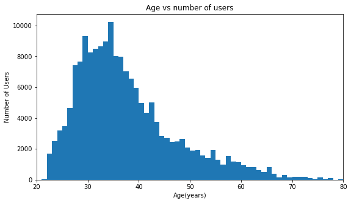

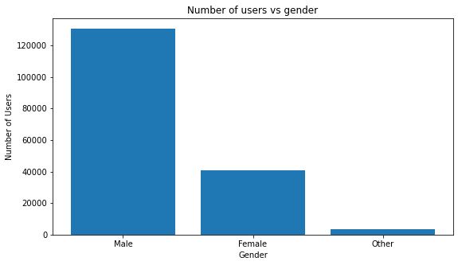

This shows that male are the frequent bike users compared to their counterparts female and other

I want to find out the user type that share their bike

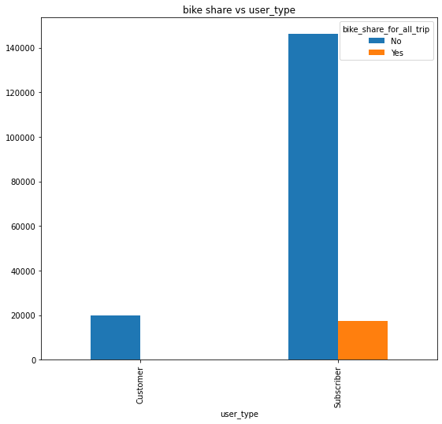

I want to find out the gender that has the longest duration type

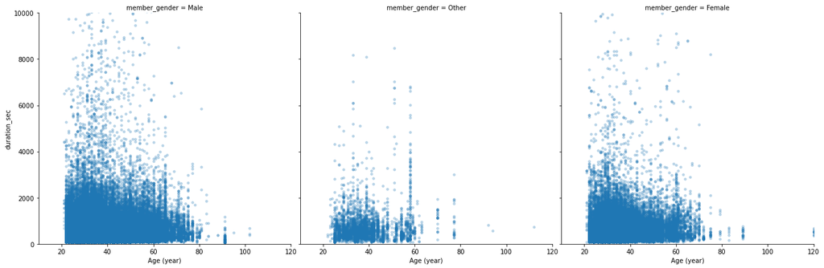